# StatData2 - Forelæsning d. 10/10-2017

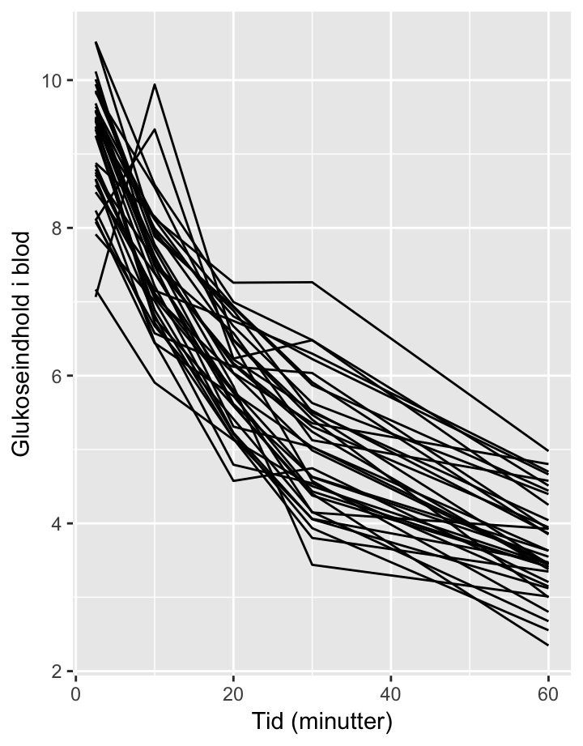

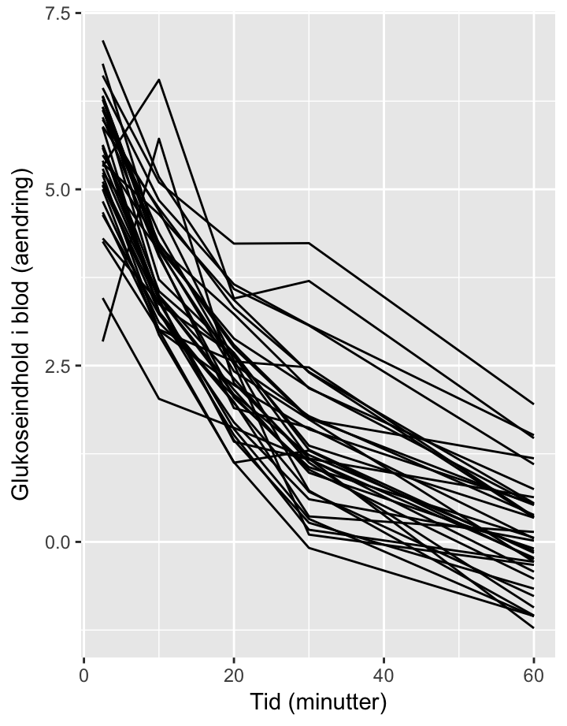

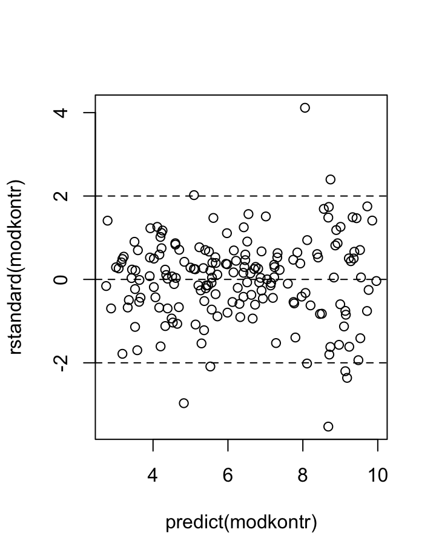

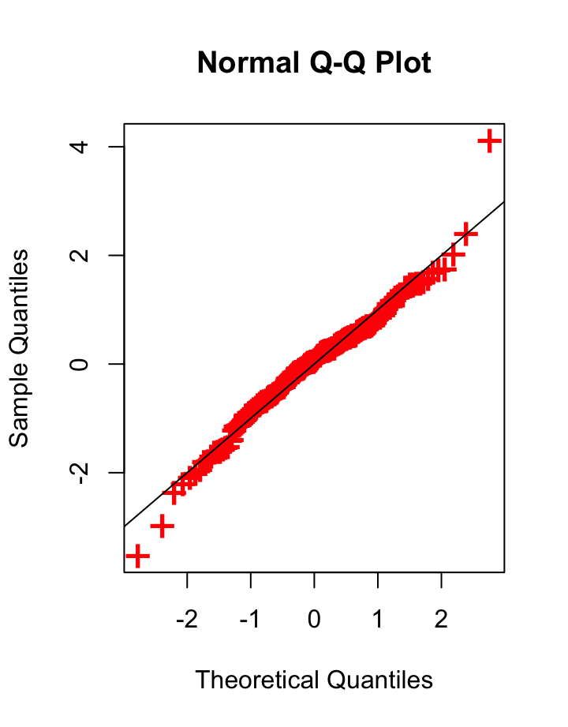

# Om data

### Forsøgsbeskrivelse

Tyve får som var drægtige med tvillinger blev tilfældigt inddelt i 2 lige store behandlingsgrupper.

- Får i den ene gruppe fik normalt foder (*prenatal = NORM*)
- Får i den anden gruppe fik foder med lavt kalorieindhold (*prenatal = LOW*)

Antal overlevende lam efter 6 måneder: 36 ud af 40

Data er venligst stillet til rådighed af Anne Hauntoft Kongsted. En supplerende beskrivelse af forsøget samt dele af nedenstående dataanalyse er findes i følgende artikel.

- Kongsted et al.: **Programming of glucose–insulin homoeostasis: long-term consequences of pre-natal versus early post-natal nutrition insults. Evidence from a sheep model**, Acta Physiol 2014, 210, 84–98.

### Indlæs data

```r
library(tidyverse)
glu_data <-read.table("../data/lam.txt", header=T)
head(glu_data)
```

```
  lamb sheep prenatal postnatal time    glu baseline
1 1114  2055     NORM      CONV  2.5 7.1661   2.9066
2 1114  2055     NORM      CONV 10.0 5.9055   2.9066
3 1114  2055     NORM      CONV 20.0 5.1310   2.9066
4 1114  2055     NORM      CONV 30.0 4.5036   2.9066
5 1114  2055     NORM      CONV 60.0 3.4464   2.9066
6 1115  2055     NORM      HCHF  2.5 8.6642   3.3730
```

### Plot data (kode)

Følgende kode viser *subject profiles* for glukose-målingerne for hvert lamb

- plot 1: glukosemålinger
- plot 2: ændring i glukose i forhold til baseline

```r
library(ggplot2)
ggplot(data = glu_data) + geom_line(aes(x = time, y = glu, group = lamb)) + labs(x = "Tid (minutter)", y = "Glukoseindhold i blod")
ggplot(data = glu_data) + geom_line(aes(x = time, y = glu - baseline, group = lamb)) + labs(x = "Tid (minutter)", y = "Glukoseindhold i blod (aendring)")
```

### Plot 1

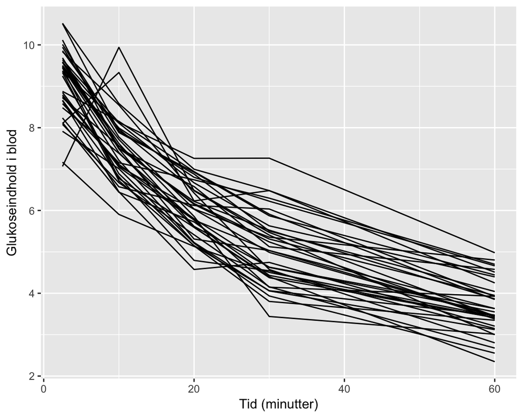

### Plot 2

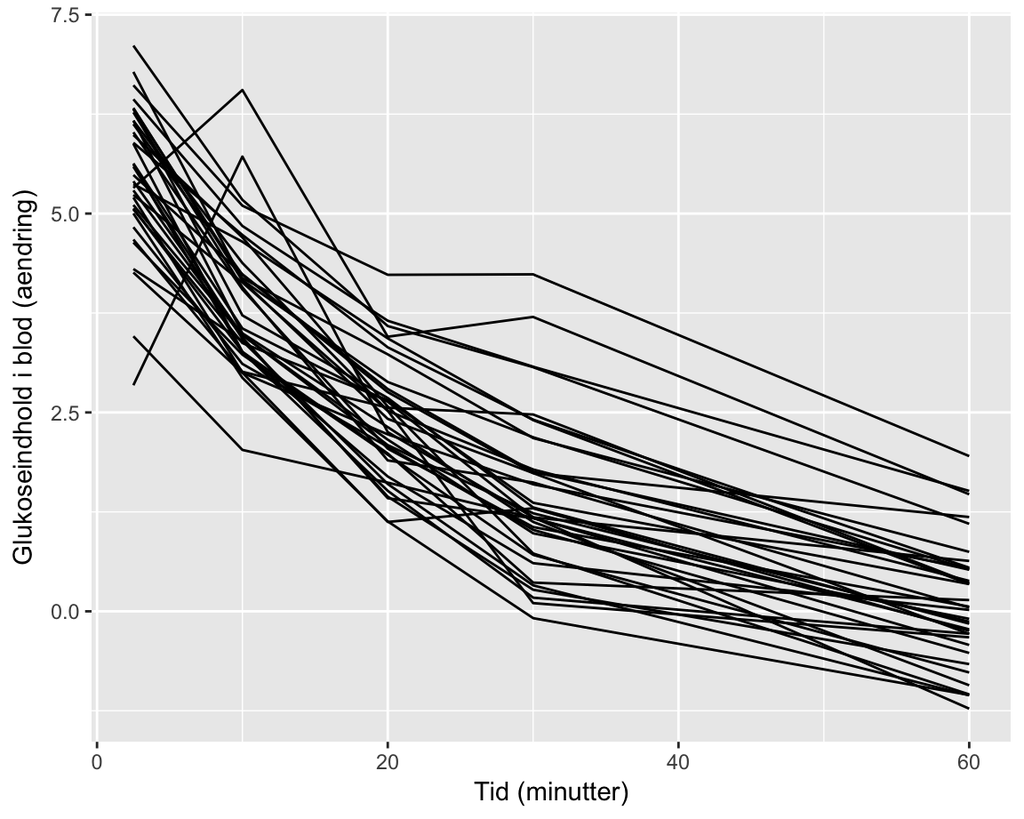

# Warm up

### Om forsøgsdesignet

Lad os i første omgang kun analysere målinger af baseline glukosen svarende til følgende datasæt

```r
glu0 <- select(filter(glu_data, time == "2.5"), - glu, - time)
head(glu0)
```

```
  lamb sheep prenatal postnatal baseline
1 1114  2055     NORM      CONV   2.9066
2 1115  2055     NORM      HCHF   3.3730
3 1116   640     NORM      CONV   3.9439
4 1117   640     NORM      HCHF   2.8303
5 1118   729     NORM      HCHF   3.5611
6 1119   729     NORM      CONV   3.7856
```

- hvilke faktorer bør indgå i analysen?
- hvilke faktorer bør indgå i analysen med tifældig effekt?
- tegn et faktordiagram og diskuter, hvilken type forsøg der er tale om?

### Tabeller

```r
with(glu0, table(prenatal, postnatal))
```

```
        postnatal
prenatal CONV HCHF
    LOW    10    7
    NORM   10    9
```

```r
with(glu0, table(prenatal, sheep))
```

```
        sheep
prenatal 577 598 605 616 640 712 718 721 729 741 743 747 791 795 809 844
    LOW    2   0   2   0   0   0   1   2   0   0   2   2   0   0   0   1
    NORM   0   2   0   2   2   2   0   0   2   1   0   0   2   2   2   0
        sheep
prenatal 861 940 966 2055
    LOW    2   1   2    0
    NORM   0   0   0    2
```

```r
with(glu0, table(postnatal, sheep))
```

```
         sheep
postnatal 577 598 605 616 640 712 718 721 729 741 743 747 791 795 809 844
     CONV   1   1   1   1   1   1   1   1   1   1   1   1   1   1   1   1
     HCHF   1   1   1   1   1   1   0   1   1   0   1   1   1   1   1   0
         sheep
postnatal 861 940 966 2055
     CONV   1   1   1    1
     HCHF   1   0   1    1
```

### Statistisk analyse (lmer)

```r
library(lme4)
m1 <- lmer(baseline ~ prenatal * postnatal + (1 | sheep), data = glu0)
m2 <- lmer(baseline ~ prenatal  + (1 | sheep), data = glu0)
anova(m2, m1)
```

```
Data: glu0
Models:
m2: baseline ~ prenatal + (1 | sheep)
m1: baseline ~ prenatal * postnatal + (1 | sheep)
   Df    AIC    BIC logLik deviance Chisq Chi Df Pr(>Chisq)
m2  4 53.959 60.293 -22.98   45.959
m1  6 57.360 66.861 -22.68   45.360 0.599      2     0.7412
```

```r
m3 <- lmer(baseline ~ 1 + (1 | sheep), data = glu0)
anova(m3, m2)
```

```
Data: glu0
Models:
m3: baseline ~ 1 + (1 | sheep)
m2: baseline ~ prenatal + (1 | sheep)
   Df    AIC    BIC  logLik deviance  Chisq Chi Df Pr(>Chisq)
m3  3 52.264 57.014 -23.132   46.264
m2  4 53.959 60.293 -22.980   45.959 0.3046      1      0.581
```

### Statistisk analyse (lme)

```r
library(nlme)
l1 <- lme(baseline ~ prenatal * postnatal, random = ~ 1 | sheep, data = glu0, method = "ML")
l2 <- lme(baseline ~ prenatal, random = ~ 1 | sheep, data = glu0, method = "ML")
l3 <- lme(baseline ~ 1, random = ~ 1 | sheep, data = glu0, method = "ML")
anova(l2, l1)
```

```
   Model df      AIC      BIC    logLik   Test   L.Ratio p-value
l2     1  4 53.95922 60.29330 -22.97961
l1     2  6 57.36021 66.86133 -22.68011 1 vs 2 0.5990097  0.7412
```

```r
anova(l3, l2)
```

```
   Model df      AIC      BIC    logLik   Test   L.Ratio p-value
l3     1  3 52.26381 57.01437 -23.13191
l2     2  4 53.95922 60.29330 -22.97961 1 vs 2 0.3045896   0.581
```

### Konklusion

Behandlingen lader ikke til at have effekt på baseline glukoseniveauet før glukosetolerancetesten.

```r
summary(m3)
```

```
Linear mixed model fit by REML ['lmerMod']
Formula: baseline ~ 1 + (1 | sheep)
   Data: glu0

REML criterion at convergence: 49.5

Scaled residuals:
    Min      1Q  Median      3Q     Max
-1.6353 -0.5532 -0.1060  0.4380  3.0871

Random effects:
 Groups   Name        Variance Std.Dev.
 sheep    (Intercept) 0.02287  0.1512
 Residual             0.19597  0.4427
Number of obs: 36, groups:  sheep, 20

Fixed effects:
            Estimate Std. Error t value
(Intercept)  3.59305    0.08147    44.1
```

```r
confint(m3)
```

```
               2.5 %    97.5 %
.sig01      0.000000 0.3798201
.sigma      0.328897 0.5893248
(Intercept) 3.429580 3.7562007
```

Baselineglukoseniveauet i populationen estimeres til 3.59305 med et 95 %-konfidensinterval på [3.429580-3.7562007].

Den totale varians på en måling af glukoseniveauet er $0.02287+0.19597$, hvoraf den del af variationen som kan tilskrives det mødrende ophov (**=sheep**) udgør ca. 10 %.

# Valg af model for gentagne målinger

### Undersøgelse af korrelationsstruktur

Følgende programlinjer bruges til at om organisere data og beregne den empiriske korrelationsmatrix. Denne matrix kan bruges til at undersøge om det ser ud til, at afhængigheden er størst mellem målinger, som er taget tæt på hindanden i tid.

(Der er marginal forskel på metode anvendt her og på slides fra dagens forelæsning)

```r
lmFit0 <- lm(glu ~ baseline + prenatal * postnatal * factor(time), data = glu_data)
res_data <- select(data.frame(glu_data, res = resid(lmFit0)), lamb, time, res) %>%
  spread(key = time, res)%>%
  select(-1)
head(res_data)
```

```
         2.5         10          20          30          60
1 -1.5647309 -1.0428709 -0.48653089 -0.04427089  0.04074911
2 -0.3472438 -0.5141327 -1.19781051 -0.59721051 -0.49501051
3  0.5482822  0.2561422  0.66548219  0.28234219  0.87616219
4 -0.1363064  0.3865047  0.31062692  0.25472692 -0.10877308
5 -0.8303719 -0.8106608  0.07436143  0.84166143  0.22596143
6 -0.1302700 -0.1511100 -0.09787001 -0.65061001  0.27110999
```

```r
cor(res_data, use = "pairwise.complete.obs")
```

```
          2.5         10        20        30         60
2.5 1.0000000 0.15247870 0.4014142 0.1614200 0.35307557
10  0.1524787 1.00000000 0.3846247 0.1477991 0.04127201
20  0.4014142 0.38462472 1.0000000 0.6405527 0.58800278
30  0.1614200 0.14779906 0.6405527 1.0000000 0.73850642
60  0.3530756 0.04127201 0.5880028 0.7385064 1.00000000
```

Det er svært at se, at der er seriel korrelation!

### Modeller med forskellig korrelationsstruktur

Neden for fittes forskellige statistiske modeller med samme middelværdi. struktur og forskellige korrelationsstrukturer. Korrelations-strukturerne kan sammenlignes ved hjælp af AIC, hvor man bør foretrække modeller med lavere AIC.

En udvidelse i forhold til, hvad vi har set tidligere er, at man både kan være interesseret i at inkludere tilfældige effekter af ‘lamb’ og ‘sheep’ sammen med en seriel korrelation inden for målinger må samme ‘lamb’. Husk, at faktoren ‘sheep’ er grovere end (dvs bestemt ud fra) faktoren ‘lamb’.

```r
glu_data$timefac<-factor(glu_data$time) ### faktor-version af 'time'
```

```r
lm0RI <- lme(glu~baseline+prenatal*postnatal*timefac,random=~1|sheep/lamb, glu_data)
lm0RInosheep<-lme(glu~baseline+prenatal*postnatal*timefac,random=~1|lamb, glu_data)
lm0diggle<-lme(glu~baseline+prenatal*postnatal*timefac,random=~1|sheep/lamb
,cor=corGaus(form=~time|sheep/lamb,nugget=T), glu_data)
lm0digglenosheep<-lme(glu~baseline+prenatal*postnatal*timefac,random=~1|lamb
,cor=corGaus(form=~time|lamb,nugget=T), glu_data)
lm0exp<-lme(glu~baseline+prenatal*postnatal*timefac,random=~1|sheep/lamb
,cor=corExp(form=~time|sheep/lamb,nugget=T), glu_data)
lm0expnosheep<-lme(glu~baseline+prenatal*postnatal*timefac,random=~1|lamb
,cor=corExp(form=~time|lamb,nugget=T), glu_data)
anova(lm0RI,lm0RInosheep,lm0diggle,lm0exp,lm0digglenosheep,lm0expnosheep)
```

```
                 Model df      AIC      BIC    logLik   Test  L.Ratio
lm0RI                1 24 392.7422 466.0921 -172.3711
lm0RInosheep         2 23 392.3882 462.6818 -173.1941 1 vs 2 1.646005
lm0diggle            3 26 396.7422 476.2046 -172.3711 2 vs 3 1.646005
lm0exp               4 26 396.7422 476.2046 -172.3711
lm0digglenosheep     5 25 396.3882 472.7943 -173.1941 4 vs 5 1.646005
lm0expnosheep        6 25 396.3882 472.7943 -173.1941
                 p-value
lm0RI
lm0RInosheep      0.1995
lm0diggle         0.6490
lm0exp
lm0digglenosheep  0.1995
lm0expnosheep
```

De to modeller uden seriel korrelation (random intercept modeller) har lavest AIC og bør foretrækkes. Dette stemmer fint med, at vi ikke kunne se nogen seriel korrelation ud fra den empiriske korrelationsmatrix.

Konklusionen bliver, at man bør vælge at bruge en af modellerne med random intercept. Man kan argumentere (ved at se på AIC) for, at man ikke behøver at have ‘sheep’ med i modellen, men det gør tilsyneladende ikke den helt store forskel, så jeg vælger at have begge de to tilf. effekter med (dvs. sheep+lamb).

### Modelkontrol

En vigtig del af modelkontrollen i modeller med tilfældige effekter kan foretages ved at lave modelkontrol for den tilsvarende model, hvor alle variable indgår med systematisk effekt.

R-koden til dette findes her (figurer ses på øvrige faneblade i menuen)

```r
modkontr <- lm(glu ~ baseline + prenatal * postnatal *  timefac + factor(sheep) + factor(lamb), data = glu_data)
plot(predict(modkontr), rstandard(modkontr))
abline(h = c(-2,0,2), lty = 2)
qqnorm(rstandard(modkontr), pch = "+", cex = 2, col = 2)
abline(0, 1)
```

### Residual plot

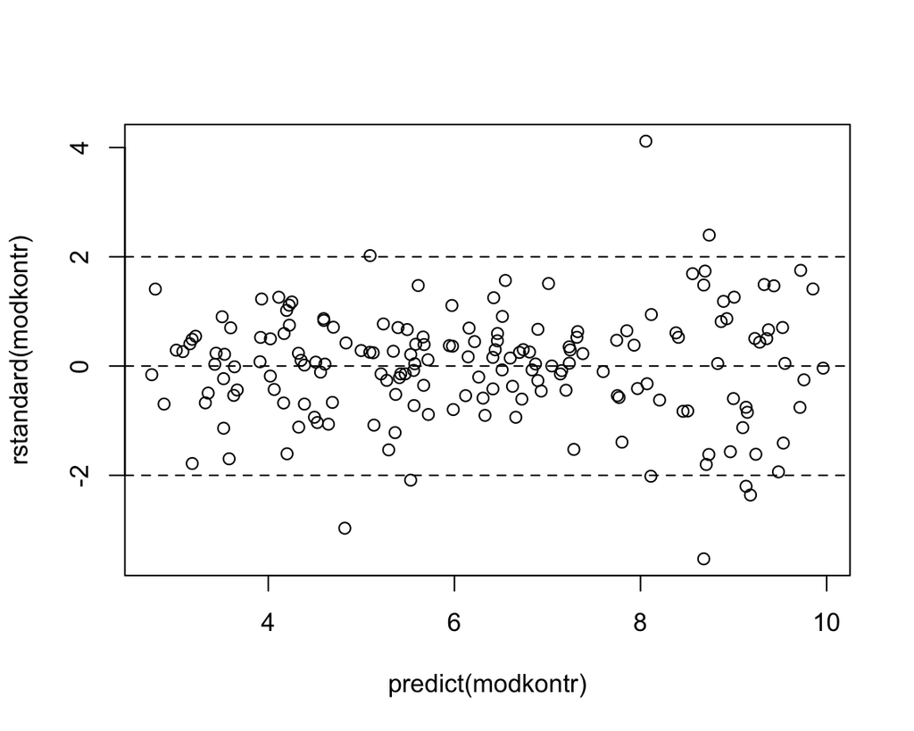

### QQ-plot

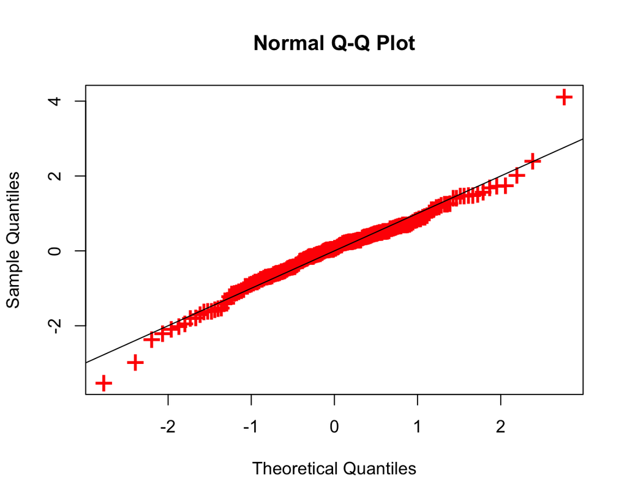

# Modelreduktion

### Effekt af baseline-måling

Der er mange forskellige muligheder for modelreduktion. Følgende skal ses som inspiration, og i praksis ville man vælge et mindre antal hypoteser man tester, med henblik på at belyse nogle på forhånd givne problemstillinger omkring behandlingens effekt.

Som udgangspunkt opfatter vi det som om vi har 4 behandlinger givet ved kombinationer af prenatal og postnatal diet. I det følgende laver vi (for overskuelighedens skyld) en faktor ‘treat’ med 4 niveauer og glemmer, at denne i virkeligheden er sammensat af prenatal og postnatal diæt.

```r
glu_data$treat <- glu_data$prenatal:glu_data$postnatal
lm0 <- lme(glu ~ baseline + treat * timefac, random = ~ 1 | sheep / lamb, data = glu_data, method = "ML")
```

Test for om baseline glukose har indflydelse på værdi af glukose under glukose-tolerance testen.

```r
lm1 <- lme(glu ~ treat * timefac, random = ~ 1|sheep/lamb, data = glu_data, method = "ML")
anova(lm1, lm0) ### p=0.09 - kunne vælge at simulere p-værdi
```

```
    Model df      AIC      BIC    logLik   Test  L.Ratio p-value
lm1     1 23 364.9620 438.1430 -159.4810
lm0     2 24 364.0864 440.4492 -158.0432 1 vs 2 2.875592  0.0899
```

```r
### simulation af p-vaerdi

sim<-simulate.lme(lm1, m2 = lm0, nsim = 50, seed = 2016)
lr.sim <- 2*(sim$alt$ML-sim$null$ML)
psim <- sum(lr.sim > 2.875592) / 50
psim
```

```
[1] 0.18
```

**Kommentar:** Som en kvik studerende bemærkede så er der inkonsistens mellem konklusionerne hvis man baserer testet på p-værdien eller, hvis man vælger modellen med lavest AIC. Der er mange forskellige metoder hvorpå man kan lave modelreduktion, og selvom vi fokuserer meget på p-værdier, så er ukritisk brug af denne metode ikke (længere) alment accepteret. I alle tilfælde må man klart beskrive (typisk i artiklens metodeafsnit) hvilken metode man har tænkt sig at præsentere, og så må man prøve at forsvare et synspunkt om, at konklusionerne ikke afhænger alt for meget af valget af model selektionsmetode.

### Additiv model

Test for, om der er en additiv effekt af de to faktorer timefac og treat. Dette test giver ikke (nødvendigvis særlig) meget mening ud fra den biologiske problemstilling: hvis der er en effekt at beh. vil man som udgangspunkt regne med, at den afhænger af tiden. Den additive model kan ikke beskrive dette!

```r
lm2<-lme(glu~treat+timefac,random=~1|sheep/lamb,data = glu_data,method="ML")
anova(lm2,lm1) ### p=0.02
```

```
    Model df     AIC      BIC   logLik   Test  L.Ratio p-value
lm2     1 11 364.990 399.9897 -171.495
lm1     2 23 364.962 438.1430 -159.481 1 vs 2 24.02806  0.0202
```

### Hovedeffekter

Det er langt mere naturligt at prøve at reducere faktoren treat til enten prenatal eller postnatal eller at fjerne treatment helt.

Dette gøres neden for:

```r
lm2a<-lme(glu~postnatal*timefac,random=~1|sheep/lamb, data = glu_data,method="ML")
anova(lm2a,lm1) ### p=0.02 - signifikant effekt af prenatal
```

```
     Model df      AIC      BIC   logLik   Test  L.Ratio p-value
lm2a     1 13 366.3799 407.7431 -170.190
lm1      2 23 364.9620 438.1430 -159.481 1 vs 2 21.41795  0.0184
```

```r
lm2b<-lme(glu~prenatal*timefac,random=~1|sheep/lamb, data = glu_data, method="ML")
anova(lm2b,lm1) ### p<.0001 - signifikant effekt af postnatal
```

```
     Model df      AIC      BIC    logLik   Test  L.Ratio p-value
lm2b     1 13 384.1097 425.4729 -179.0548
lm1      2 23 364.9620 438.1430 -159.4810 1 vs 2 39.14771  <.0001
```

```r
lm7<-lme(glu~timefac,random=~1|sheep/lamb, data = glu_data,method="ML")
anova(lm7,lm1) ### p=0.0001 - signifikant effekt af behandling hvis man i eet test forsøger at fjerne behandling
```

```
    Model df      AIC      BIC    logLik   Test  L.Ratio p-value
lm7     1  8 378.4048 403.8591 -181.2024
lm1     2 23 364.9620 438.1430 -159.4810 1 vs 2 43.44283   1e-04
```

### ‘time’ som kovariat

Alternativt kan man undersøge det rimelige i at lade ‘time’ indgå som en numerisk variabel i stedet for som faktor.

Dette svarer til at teste om glukose-indholdet afhænger lineært af time.

```r
lm3<-lme(glu~treat*time,random=~1|sheep/lamb, data = glu_data,method="ML")
anova(lm3,lm1) ### p<0.0001
```

```
    Model df      AIC      BIC    logLik   Test  L.Ratio p-value
lm3     1 11 499.6195 534.6192 -238.8098
lm1     2 23 364.9620 438.1430 -159.4810 1 vs 2 158.6576  <.0001
```

Man kan også undersøge mere avancerede matematiske sammenhænge til beskrivelse af sammenhæng mellem glukoseindhold og ‘time’ under glukose-tolerance testen.

Her testes om glukose-indholdet afhænger af time gennem et 2.gradspolynomium.

```r
lm4<-lme(glu~treat*time+treat:I(time^2),random=~1|sheep/lamb, data = glu_data,method="ML")
lm4alt<-lme(glu~treat+treat:time+treat:I(time^2)-1,random=~1|sheep/lamb, data = glu_data,method="ML")
anova(lm4,lm1) ### vi kunne vælge at godtage dette
```

```
    Model df     AIC      BIC    logLik   Test  L.Ratio p-value
lm4     1 15 365.127 412.8538 -167.5635
lm1     2 23 364.962 438.1430 -159.4810 1 vs 2 16.16503  0.0401
```

### Gruppen ‘LOW:HCHF’

```r
glu_data$treatny <- factor(glu_data$treat == "LOW:HCHF")
lm6<-lme(glu ~ treatny * timefac, random = ~1|sheep/lamb, data = glu_data, method = "ML")
anova(lm6,lm1) ### godkendt
```

```
    Model df      AIC      BIC    logLik   Test  L.Ratio p-value
lm6     1 13 353.5237 394.8869 -163.7618
lm1     2 23 364.9620 438.1430 -159.4810 1 vs 2 8.561694  0.5741
```

```r
lm7<-lme(glu~timefac,random=~1|sheep/lamb, data = glu_data,method="ML")
anova(lm7,lm6) ### forkastes
```

```
    Model df      AIC      BIC    logLik   Test  L.Ratio p-value
lm7     1  8 378.4048 403.8591 -181.2024
lm6     2 13 353.5237 394.8869 -163.7618 1 vs 2 34.88113  <.0001
```

# Konklusioner

### Estimater (middelværdistruktur)

Vi genfitter slutmodellen og kigger på parameterestimaterne

```r
lm6refit <- lme(glu~timefac+treatny:timefac-1
,random=~1|sheep/lamb,data = glu_data,method="REML")
summary(lm6refit)$tTable
```

```
                           Value Std.Error  DF   t-value       p-value
timefac2.5             9.0253657 0.1351709 133 66.770014 3.658540e-104
timefac10              7.2008933 0.1351709 133 53.272494  1.372468e-91
timefac20              5.7767088 0.1387104 133 41.645835  3.582805e-78
timefac30              4.8162278 0.1351709 133 35.630644  6.709771e-70
timefac60              3.5540243 0.1351709 133 26.292813  1.558944e-54
timefac2.5:treatnyTRUE 0.3228364 0.2757303 133  1.170841  2.437561e-01
timefac10:treatnyTRUE  1.5252088 0.2757303 133  5.531525  1.622419e-07
timefac20:treatnyTRUE  1.0499504 0.2776905 133  3.781009  2.350113e-04
timefac30:treatnyTRUE  1.3236314 0.2757303 133  4.800457  4.195089e-06
timefac60:treatnyTRUE  0.6350920 0.2757303 133  2.303309  2.281287e-02
```

De første 5 parameterestimater angiver de gennemsnitlige glukoseværdier for lam under en glukose-tolerance test til tidspunkterne 2.5, 10, 20, 30 og 60 minutter for alle behandlingsgrupper bortset fra *LOW:HCHF*.

De øvrige 5 parameterestimater angiver forskellene mellem glukoseværdierne til hvert af tidspunkterne 2.5, 10, 20, 30 og 60 for gruppe *LOW:HCHF* i forhold til de øvrige grupper. Vi ser et signifikant forhøjet niveau af glukose til alle tidspunkterne bortset fra tid 2.5 minutter. Dette tyder på, at *LOW:HCHF* lam er langsommere til at fjerne glukosen fra blodet.

### Konfidensintervaller

Konfidensintervaller ses her

```r
intervals(lm6refit)
```

```
Approximate 95% confidence intervals

 Fixed effects:
                             lower      est.     upper
timefac2.5              8.75800281 9.0253657 9.2927286
timefac10               6.93353040 7.2008933 7.4682562
timefac20               5.50234505 5.7767088 6.0510725
timefac30               4.54886488 4.8162278 5.0835907
timefac60               3.28666143 3.5540243 3.8213872
timefac2.5:treatnyTRUE -0.22254743 0.3228364 0.8682202
timefac10:treatnyTRUE   0.97982498 1.5252088 2.0705926
timefac20:treatnyTRUE   0.50068937 1.0499504 1.5992115
timefac30:treatnyTRUE   0.77824764 1.3236314 1.8690152
timefac60:treatnyTRUE   0.08970823 0.6350920 1.1804758
attr(,"label")
[1] "Fixed effects:"

 Random Effects:
  Level: sheep
                    lower      est.     upper
sd((Intercept)) 0.1451523 0.3007142 0.6229941
  Level: lamb
                    lower      est.    upper
sd((Intercept)) 0.1656101 0.3017676 0.549868

 Within-group standard error:
    lower      est.     upper
0.4852790 0.5469781 0.6165216
```